# Лабораторная работа №4. Работа с программными пакетами

Дисциплина: Основы администрирования операционных систем

Мацюк Константин Владимирович

1032253640@rudn.ru

Российский университет дружбы народов

# Вводная часть

## Актуальность, объект и предмет

- Работа с программными пакетами — базовая задача администрирования Linux
- Репозитории и менеджеры пакетов определяют установку и обновление ПО
- Необходимо уверенно работать с `dnf` и `rpm`
- Важна безопасная установка/удаление пакетов и анализ их содержимого
- **Объект:** репозитории и программные пакеты в ОС типа Linux
- **Предмет:** менеджеры пакетов `dnf`, `rpm`; конфигурационные файлы `/etc/dnf/dnf.conf`, `/etc/dnf/`, `/etc/yum.repos.d/`, `/var/cache/dnf/`, `/var/log/dnf.log`

## Цели, задачи, материалы и методы

- **Цель:** получить навыки работы с репозиториями и менеджерами пакетов
- **Задачи:**
  - Изучить, как и в каких файлах подключаются репозитории
  - Изучить основные возможности `dnf` (поиск, установка, обновление, удаление, история)
  - Повторить установку/удаление пакета через `dnf`
  - Повторить установку/удаление пакета через `rpm`
- **Материалы и методы:** ОС Linux (RHEL/CentOS/Fedora); команды `dnf`, `rpm`, `find`, `which`, `man`; пакеты `nmap`, `lynx`, `dnsmasq`

# Теоретическое введение

## Пакетный менеджер dnf и его конфигурация

- `dnf` используется в популярных Linux-дистрибутивах для установки, удаления и других действий с пакетами
- Основные команды `dnf` — раздел 4.2.1; опции — 4.2.2; `yum-utils` — 4.2.3
- Конфигурационные файлы — 4.2.4; опции `dnf.conf` — 4.2.5; плагины — 4.2.6; прокси — 4.2.7

Таблица 1: Основные конфигурационные файлы и каталоги dnf

| Файл/каталог | Описание |
| --- | --- |
| `/etc/dnf/dnf.conf` | Основной конфигурационный файл `dnf` |
| `/etc/dnf/` | Директория с конфигурациями (например, dnf-плагины) |
| `/etc/yum.repos.d/` | Директория с информацией о репозиториях |
| `/var/cache/dnf/` | Директория, где `dnf` хранит кэш и файлы базы (по умолчанию) |
| `/var/log/dnf.log` | Лог-файл выполнения транзакций (по умолчанию) |

# Выполнение лабораторной работы

## Работа с репозиториями

- В консоли перешёл в режим работы суперпользователя, выполнив команду `su -` (рис. 1)
- Перешёл в каталог `/etc/yum.repos.d` и изучил содержание каталога и файлов репозиториев (рис. 2)
- Вывел на экран список репозиториев командой `dnf repolist` (рис. 3)
- Полученная информация показывает подключённые репозитории: appstream, baseos, epel, extras, yarn

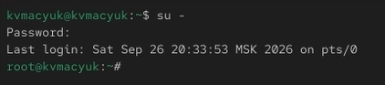

Рисунок 1: Получение прав root

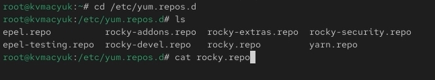

Рисунок 2: Переход в каталог репозиториев

## Просмотр списка активных репозиториев

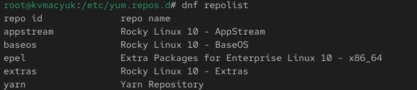

Рисунок 3: Просмотр списка активных репозиториев

## Поиск пакета user

- Вывел на экран список пакетов, в названии или описании которых есть слово `user`, командой `dnf search user` (рис. 4, рис. 5)

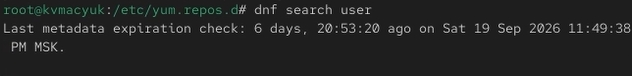

Рисунок 4: Поиск пакета (начало)

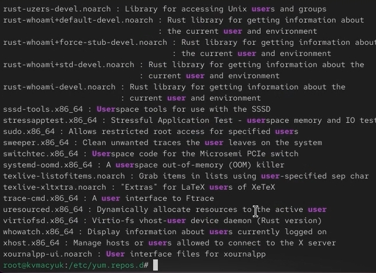

Рисунок 5: Результаты поиска

## Установка nmap: поиск и информация

- Установил `nmap`, предварительно изучив информацию по имеющимся пакетам (рис. 6—рис. 8)

```bash
dnf search nmap
dnf info nmap
dnf install nmap
dnf install nmap\*
```

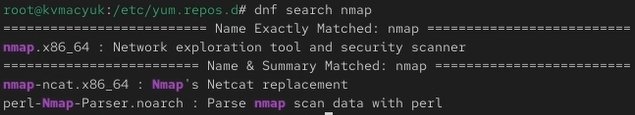

Рисунок 6: Поиск пакета nmap

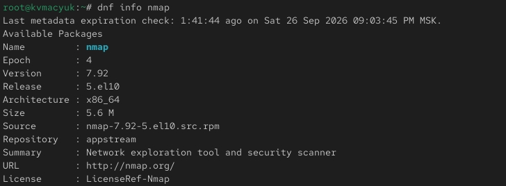

Рисунок 7: Информация о пакете (начало)

## Информация о пакете nmap (продолжение)

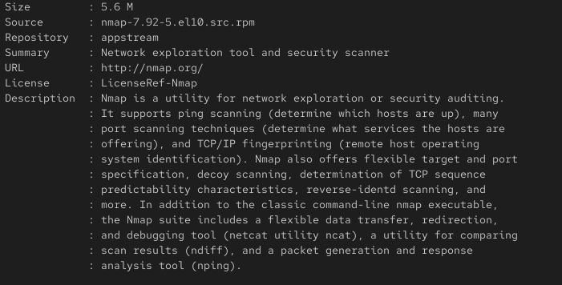

Рисунок 8: Информация о пакете (продолжение)

## Установка nmap

- Разница между `dnf install nmap` и `dnf install nmap*`: первая команда устанавливает только пакет `nmap`, вторая — все пакеты, имя которых начинается с `nmap` (например, `nmap-ncat`). В моем случае все пакеты, имя которых начинается с `nmap` уже установлены (рис. 9, рис. 10)

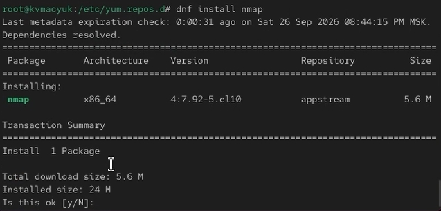

Рисунок 9: Установка nmap

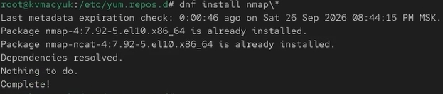

Рисунок 10: Установка nmap*

## Удаление nmap

- Удалил `nmap` (рис. 11, рис. 12)

```bash
dnf remove nmap
dnf remove nmap\*
```

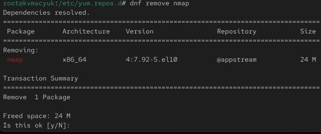

Рисунок 11: Удаление пакета nmap

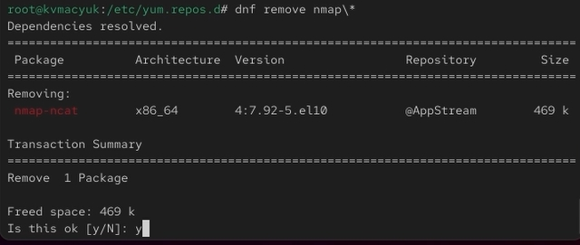

Рисунок 12: Удаление сопутствующих пакетов

## Работа с группами пакетов: список и информация

- Получил список имеющихся групп пакетов, затем установил группу пакетов RPM Development Tools (рис. 13—рис. 15)

```bash
dnf groups list
LANG=C dnf groups list
dnf groups info "RPM Development Tools"
dnf groupinstall "RPM Development Tools"
```

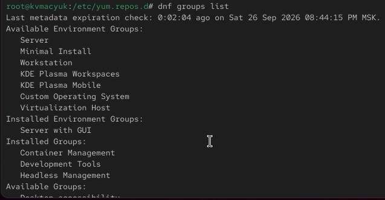

Рисунок 13: Список групп пакетов

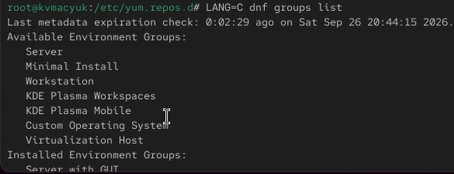

Рисунок 14: Список групп с локализацией

## Информация о группе RPM Development Tools

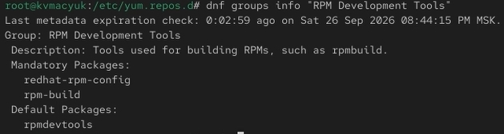

Рисунок 15: Информация о группе RPM Development Tools

## Установка группы RPM Development Tools

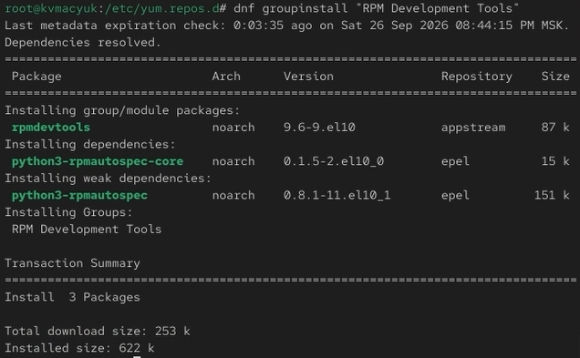

Рисунок 16: Установка группы RPM Development Tools

## Удаление группы пакетов и история dnf

- Для удаления группы пакетов RPM Development Tools воспользовался командой `dnf groupremove "RPM Development Tools"` (рис. 17)
- Посмотрел историю использования команды `dnf` и отменил последнее действие (рис. 18, рис. 19)

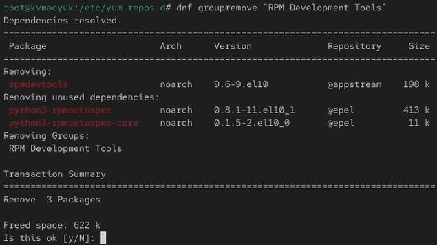

Рисунок 17: Удаление группы RPM Development Tools

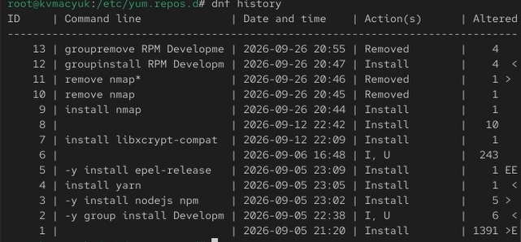

Рисунок 18: История транзакций dnf

```bash
dnf history
dnf history undo 13
```